# Plotting Time Series

2025-07-31

## Graphics

- Plots allow us to identify:
  - Patterns;
  - Unusual observations;
  - Changes over time;
  - Relationships between variables.

# 1. Time plots

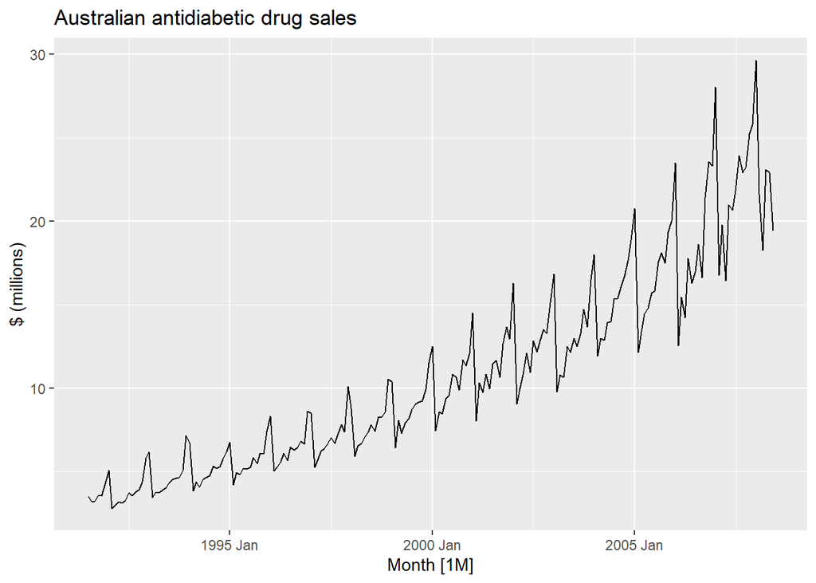

```r
#Create the univariate time series we are interested in:

PBS |>
  filter(ATC2 == "A10") |>
  select(Month, Concession, Type, Cost) |>
  summarise(TotalC = sum(Cost)) |>
  mutate(Cost = TotalC / 1e6) -> a10

#Plot
a10 |>
  autoplot(Cost) +
  labs(y = "$ (millions)", title = "Australian antidiabetic drug sales")
```

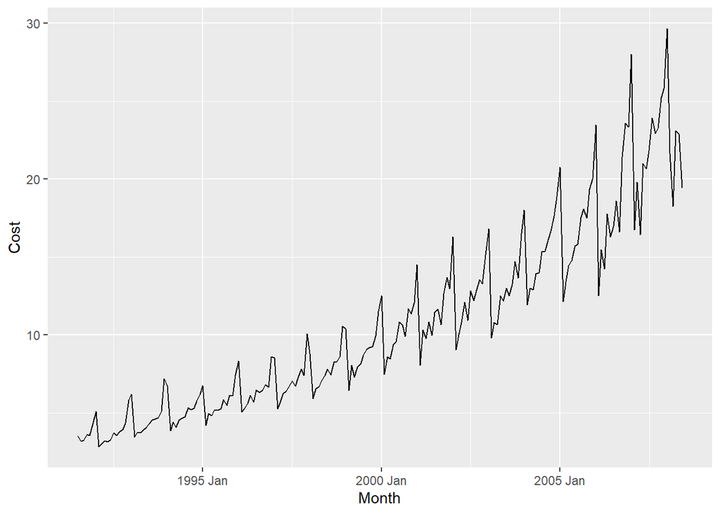

```r
a10 |>
  ggplot(aes(x=Month, y=Cost)) +
  geom_line()
```

Sometimes it is also helpful to plot additional points:

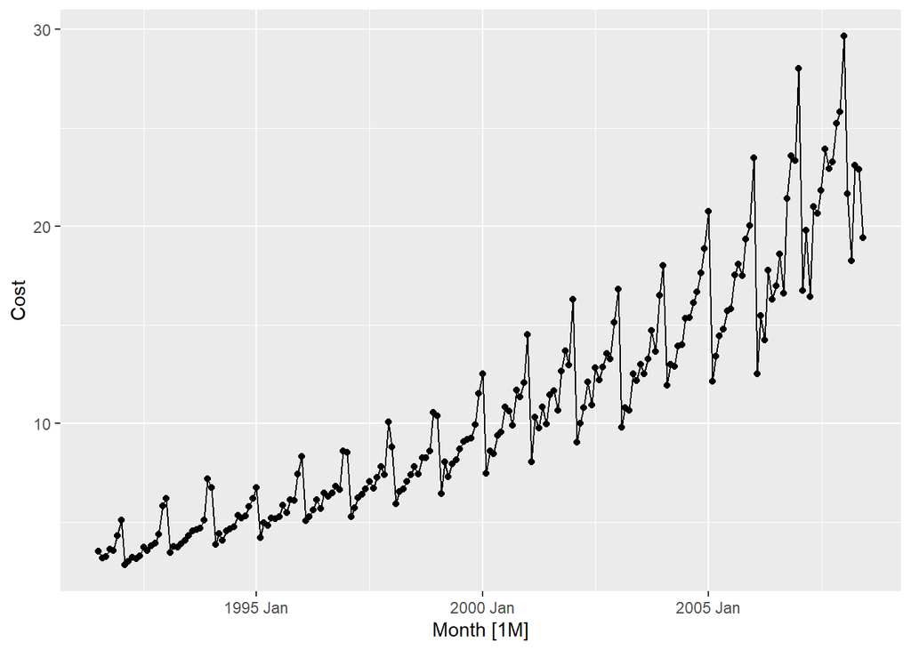

```r
#Plot
a10 |>
  autoplot(Cost) +
  geom_point()
```

The plot clearly indicates that there are regular spikes at some month each year. These spikes are then followed by a downturn. There also seems to be a nonlinear trend where the cost is increasing over time. Moreover, the difference between spike and downturn increases over time! This is in fact a typical pattern

## Ansett airlines

We now consider several ($n$) time series, in the form of different airports + classes:

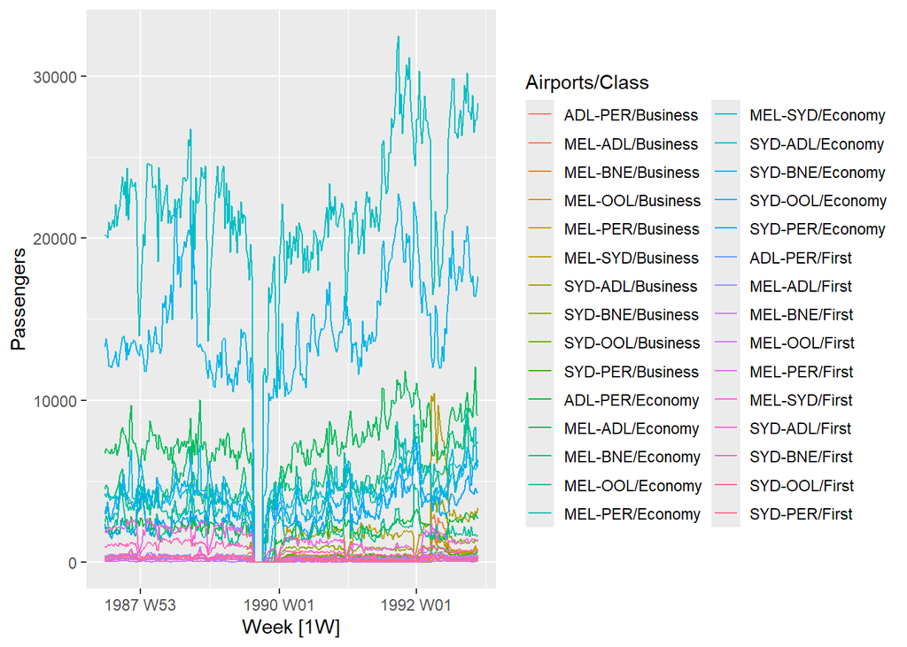

```r
ansett |>
  autoplot(Passengers)
```

We now consider only the $n=10$ time series of the economy class.

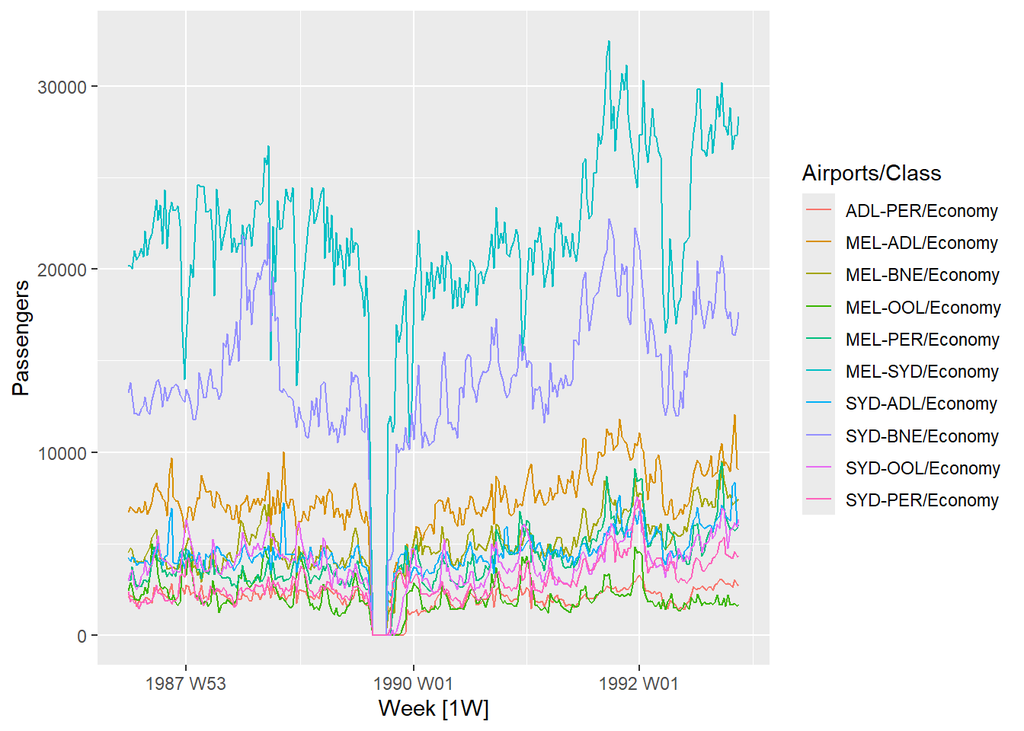

```r
# Under plot Economy class in 10 routes
ansett |>
  filter(Class == "Economy") |>
  autoplot(Passengers)
```

Instead we can also filter for the routes MEL-SYD $(n=3)$:

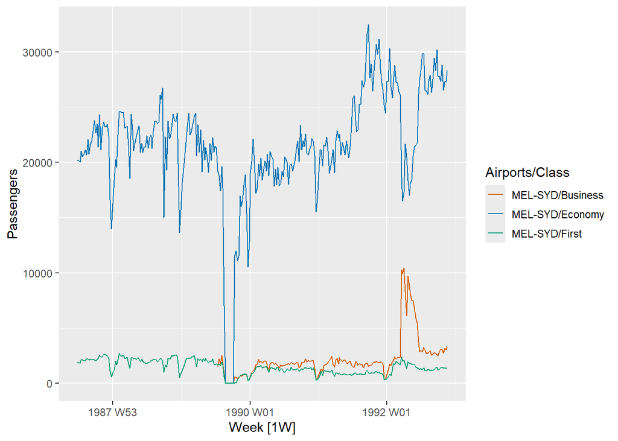

```r
# Only look at one route
ansett |>
  filter(Airports == "MEL-SYD") |>
  autoplot(Passengers)
```

Note the zeros in all three time series! These were strikes. Also there is an interesting period where some of the Economy class was replaced by business class, so that one goes down the other goes up.

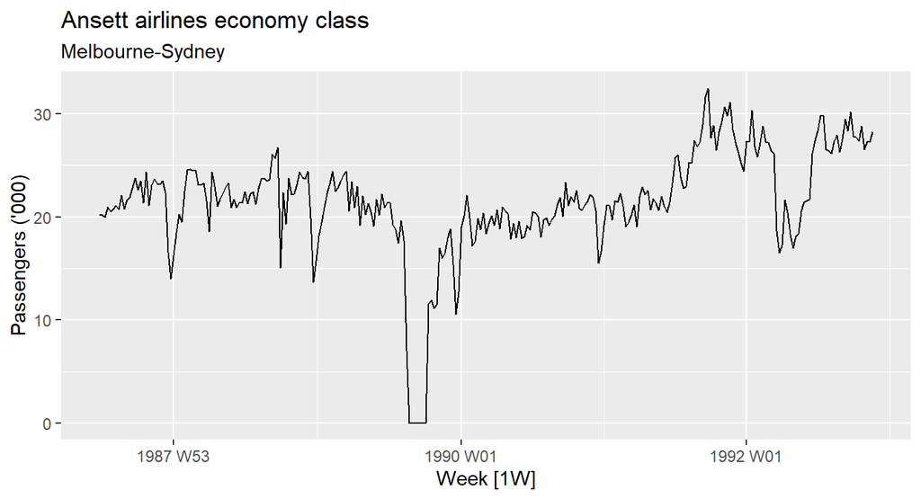

# 2. Time series patterns

## Time series components

- seasonal pattern constant length; cyclic pattern variable length
- average length of cycle longer than length of seasonal pattern
- magnitude of cycle more variable than magnitude of seasonal pattern

Consider the following example of Australian electricity production:

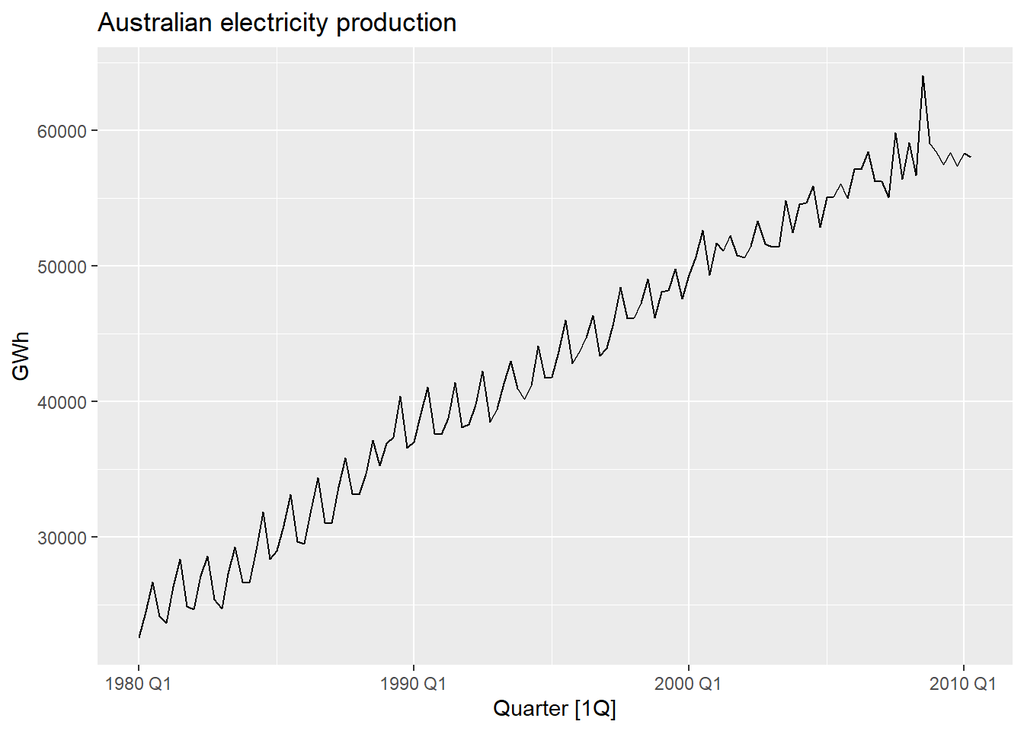

```r
aus_production |>
  filter(year(Quarter) >= 1980) |>
  autoplot(Electricity) +
  labs(y = "GWh", title = "Australian electricity production")
```

Clearly there is a long term increase (i.e. trend). There is a clear seasonal component with regular peaks every 4 observations. Note that it would not have been necessary to check the plot for this, these features are pretty obvious for electricity data (expert knowledge).

Let’s consider another example:

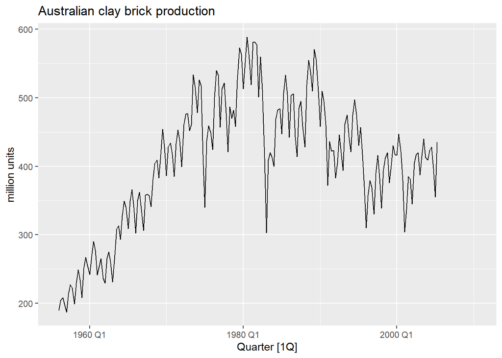

```r
aus_production |>
  autoplot(Bricks) +
  labs(y = "million units", title = "Australian clay brick production")
```

For the first half, there is a strong increasing trend in brick production. Then there are two big busts/recessions. There is also a clear cyclical component.

Another Example concerns Retail Employment:

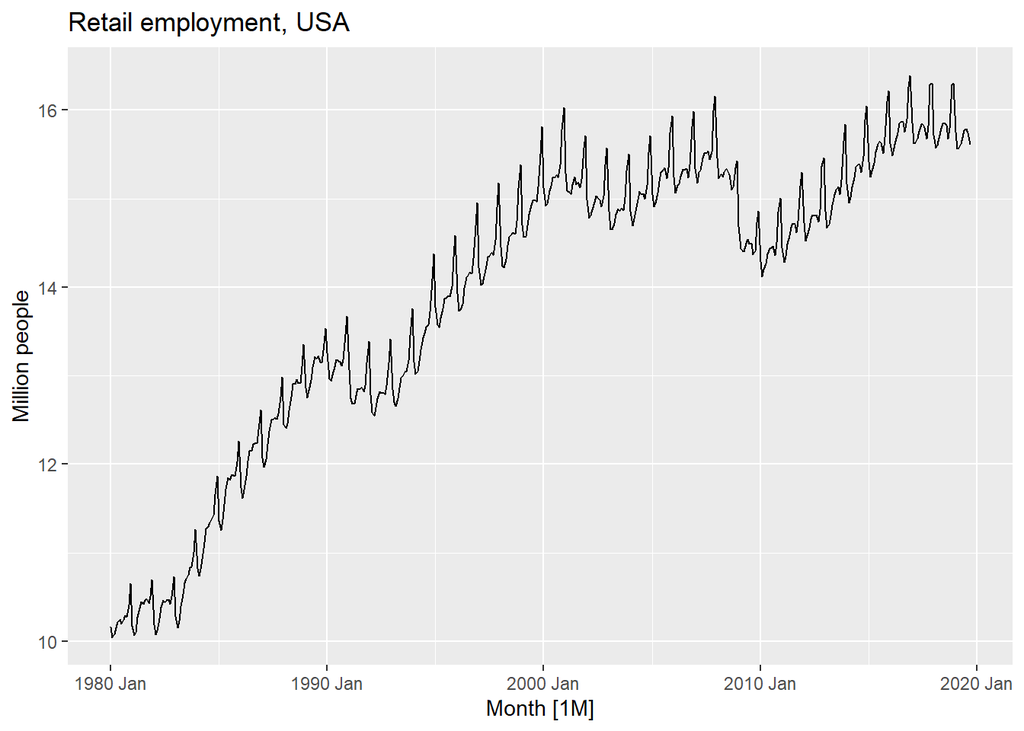

```r
us_employment |>
  filter(Title == "Retail Trade", year(Month) >= 1980) |>
  autoplot(Employed / 1e3) +
  labs(y = "Million people", title = "Retail employment, USA")
```

Strong seasonal patterns plus trend. There is however also a cyclical component with strong increases and cycles of slowdowns.

Similar patterns occur in stock prices:

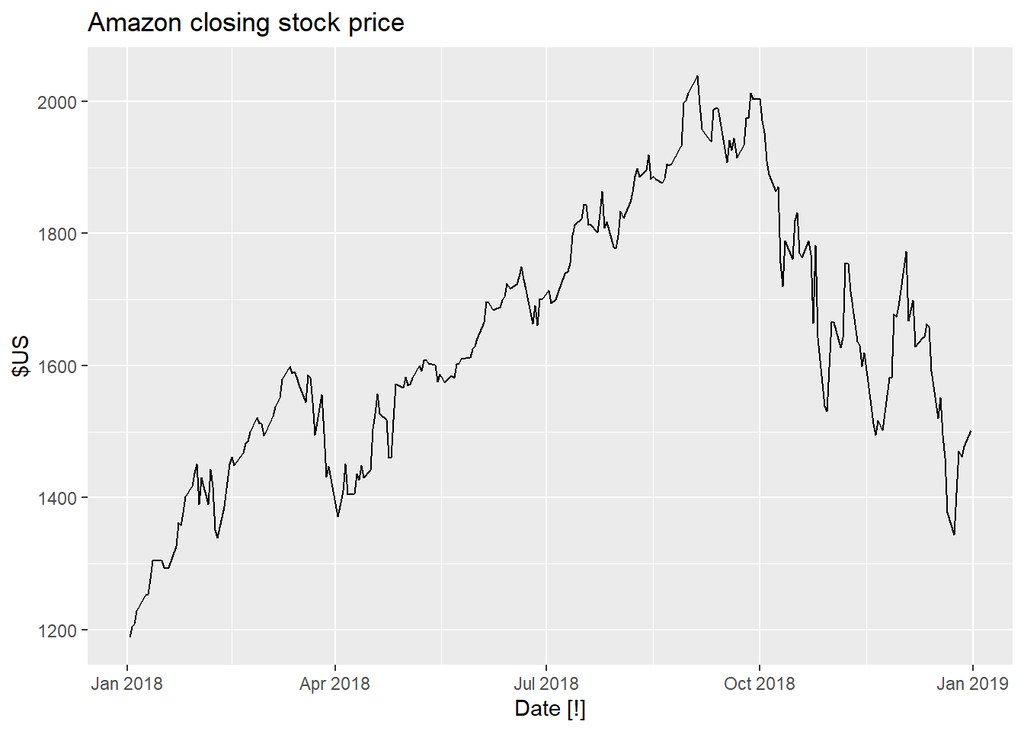

```r
gafa_stock |>
  filter(Symbol == "AMZN", year(Date) >= 2018) |>
  autoplot(Close) +
  labs(y = "$US", title = "Amazon closing stock price")
```

However financial data is generally somewhat special, we will treat this in later contexts (e.g. random walks).

Another, more regular example is the annual number of Lynx trapped in Canada:

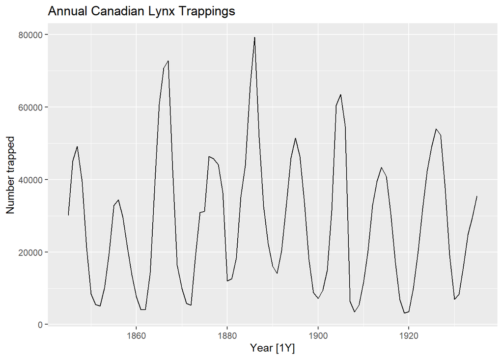

```r
pelt |>
  autoplot(Lynx) +
  labs(y = "Number trapped", title = "Annual Canadian Lynx Trappings")
```

There is a clear cycle here (over several years), which corresponds to the lifecycle of the Lynx.

## Seasonal or cyclic?

- seasonal pattern constant length; cyclic pattern variable length
- average length of cycle longer than length of seasonal pattern
- magnitude of cycle more variable than magnitude of seasonal pattern

# 3. Seasonal Plots

We now consider examples of how to analyse seasonality with plots,

```r
PBS |>
  filter(ATC2 == "A10") |>
  select(Month, Concession, Type, Cost) |>
  summarise(TotalC = sum(Cost)) |>
  mutate(Cost = TotalC / 1e6) -> a10
```

## Reminder: a10 time plot

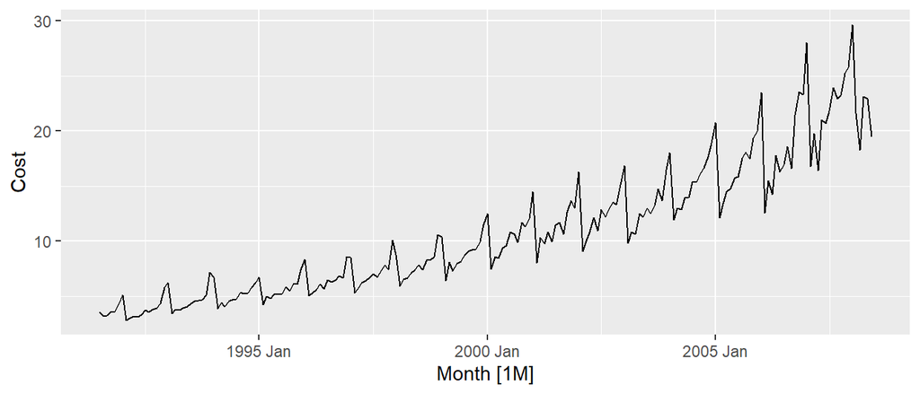

```r
a10 |>
  autoplot(Cost)
```

The plot clearly indicates that there are regular spikes at some month each year. These spikes are then followed by a downturn. There also seems to be a nonlinear trend where the cost is increasing over time. Moreover, the difference between spike and downturn increases over time! This is in fact a typical pattern.

## Seasonal plots

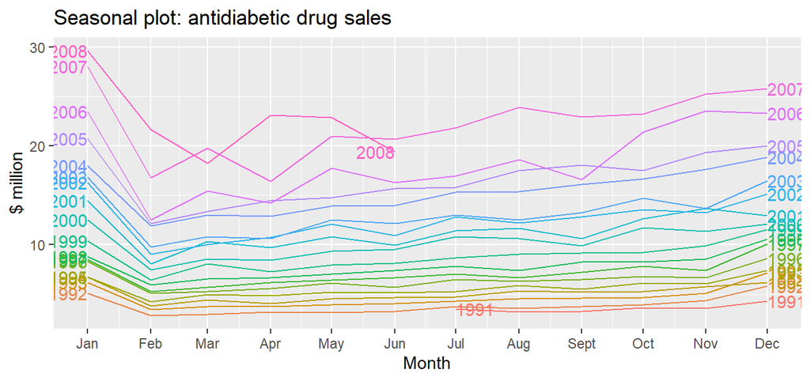

```r
a10 |> gg_season(Cost, labels = "both") +
  labs(y = "$ million", title = "Seasonal plot: antidiabetic drug sales")
```

Now the data is plotted per year agains the month (Season=Month here). We can clearly see an increase from year to year. Moroever, we see the spike from before in January and a drop in February.

- Data plotted against the individual “seasons” in which the data were observed. (In this case a “season” is a month.)
- Something like a time plot except that the data from each season are overlapped.
- Enables the underlying seasonal pattern to be seen more clearly, and also allows any substantial departures from the seasonal pattern to be easily identified.
- In R: `gg_season()`

## Quarterly Australian Beer Production

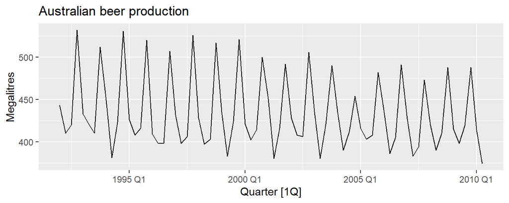

```r
beer <- aus_production |>
   select(Quarter, Beer) |> filter(year(Quarter) >= 1992)
beer |> autoplot(Beer) +
  labs(title = "Australian beer production", y = "Megalitres")
```

Again we see highly seasonal data (production increases at the beginning of summer). However its hard to identify from this plot in which quarter the spike actually happens.

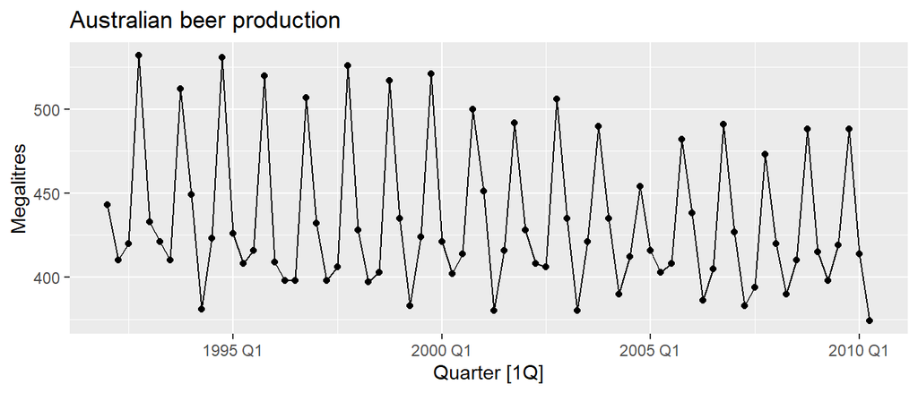

```r
beer |> autoplot(Beer) + geom_point() +
  labs(title = "Australian beer production", y = "Megalitres")
```

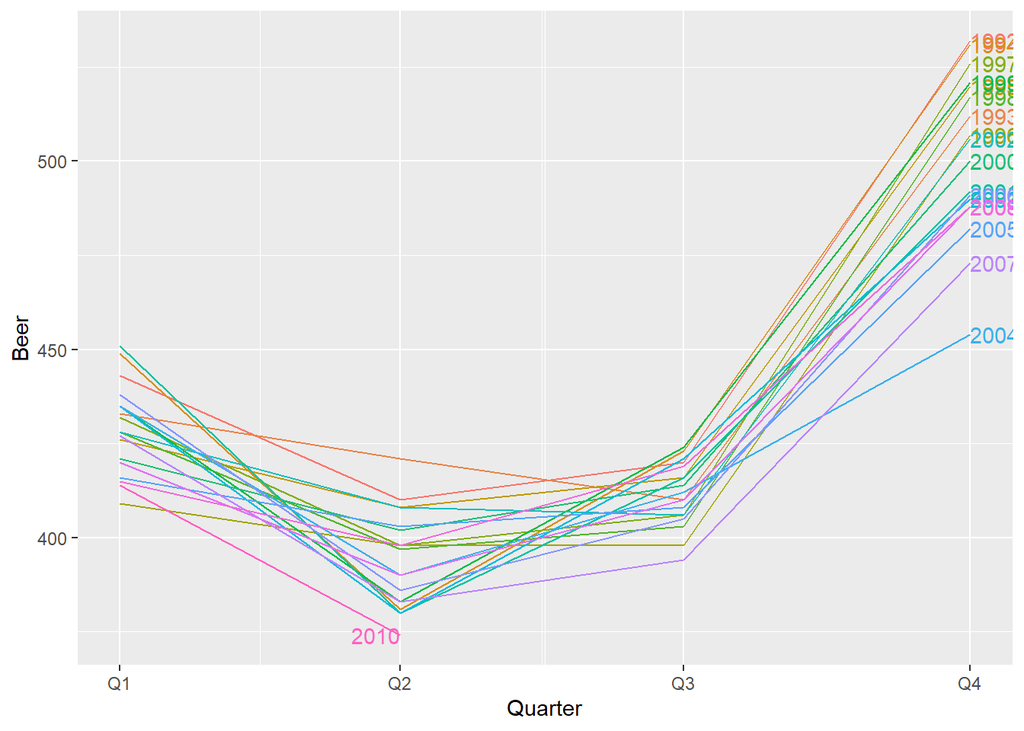

```r
beer |> gg_season(Beer, labels = "right")
```

Now in this plot, we can clearly see the spike happening in Q4! There also seems to be a certain downward trend, though 2004 appears to be an outlier! (Ask for expert knowledge here if possible)

## Multiple seasonal periods

```r
vic_elec
```

```
## # A tsibble: 52,608 x 5 [30m] <Australia/Melbourne>
##    Time                Demand Temperature Date       Holiday
##    <dttm>               <dbl>       <dbl> <date>     <lgl>
##  1 2012-01-01 00:00:00  4383.        21.4 2012-01-01 TRUE
##  2 2012-01-01 00:30:00  4263.        21.0 2012-01-01 TRUE
##  3 2012-01-01 01:00:00  4049.        20.7 2012-01-01 TRUE
##  4 2012-01-01 01:30:00  3878.        20.6 2012-01-01 TRUE
##  5 2012-01-01 02:00:00  4036.        20.4 2012-01-01 TRUE
##  6 2012-01-01 02:30:00  3866.        20.2 2012-01-01 TRUE
##  7 2012-01-01 03:00:00  3694.        20.1 2012-01-01 TRUE
##  8 2012-01-01 03:30:00  3562.        19.6 2012-01-01 TRUE
##  9 2012-01-01 04:00:00  3433.        19.1 2012-01-01 TRUE
## 10 2012-01-01 04:30:00  3359.        19.0 2012-01-01 TRUE
## # ℹ 52,598 more rows
```

Here we have a dummy variable that signals if we have a holiday or not!

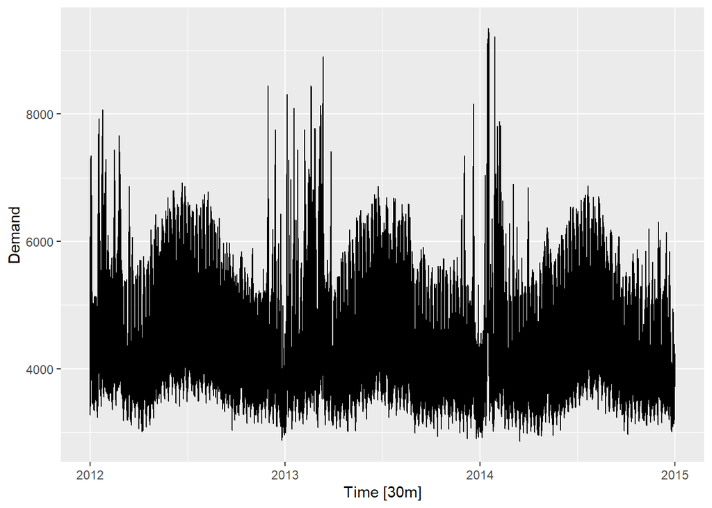

```r
vic_elec |> autoplot()
```

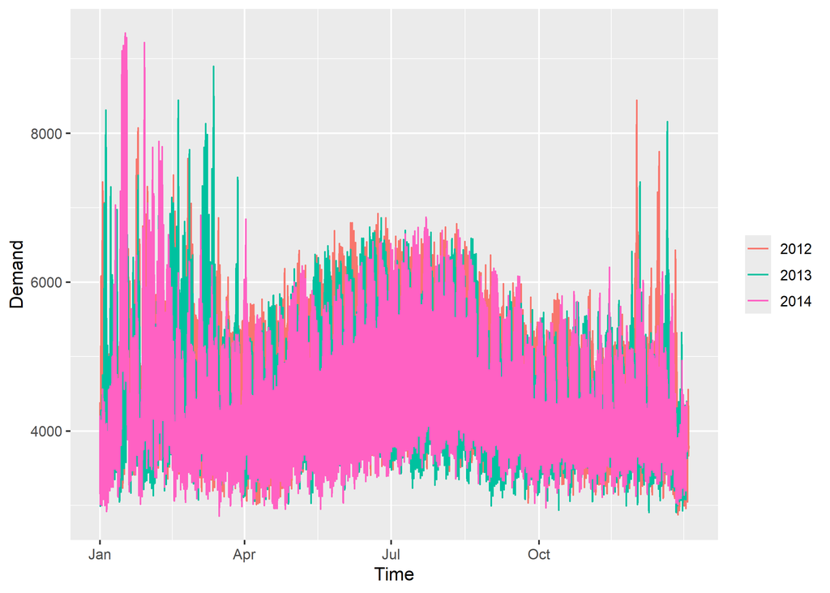

```r
vic_elec |> gg_season(Demand)
```

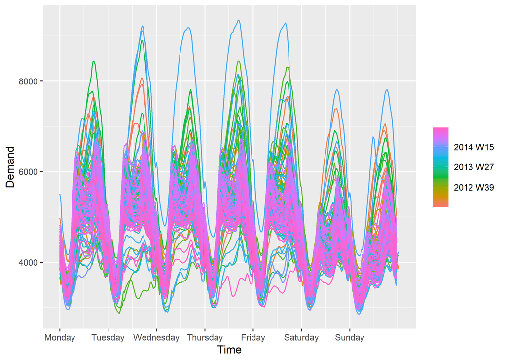

```r
vic_elec |> gg_season(Demand, period = "week")
```

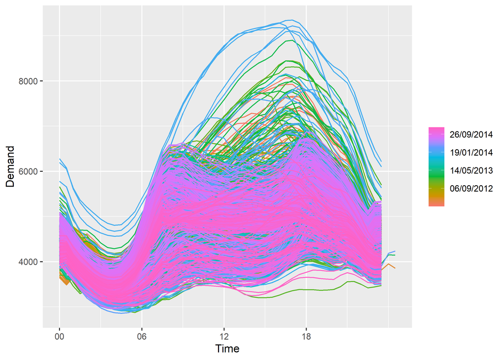

```r
vic_elec |> gg_season(Demand, period = "day")
```

Between midnight and 4am there is lowest demand. Then people wake up and demand increases, during the day demand slows down before picking up again during 6 pm. There are 3 days which have extra observations, which arise because of daylight saving time.

#3. Seasonal Subseries Plots

```r
PBS |>
  filter(ATC2 == "A10") |>
  select(Month, Concession, Type, Cost) |>
  summarise(TotalC = sum(Cost)) |>
  mutate(Cost = TotalC / 1e6) -> a10

tourism <- tourism |>
  mutate(
    State = recode(State,
      "Australian Capital Territory" = "ACT",
      "New South Wales" = "NSW",
      "Northern Territory" = "NT",
      "Queensland" = "QLD",
      "South Australia" = "SA",
      "Tasmania" = "TAS",
      "Victoria" = "VIC",
      "Western Australia" = "WA"
    )
  )
```

## Seasonal subseries plots

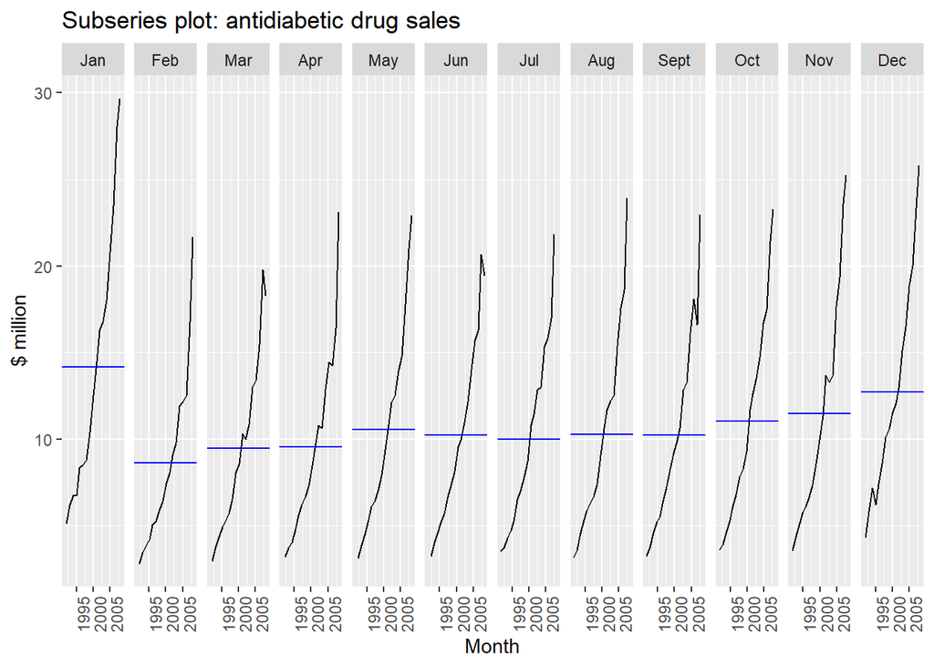

```r
a10 |>
  gg_subseries(Cost) +
  labs(y = "$ million", title = "Subseries plot: antidiabetic drug sales")
```

Here we extract all the data for a given month (i.e. January) and plot them in separate plots. Blue lines are the average (monthly) values. Again January tends to have the higest values with a drop in February.

- Data for each season collected together in time plot as separate time series.
- Enables the underlying seasonal pattern to be seen clearly, and changes in seasonality over time to be visualized.
- In R: `gg_subseries()`

## Quarterly Australian Beer Production

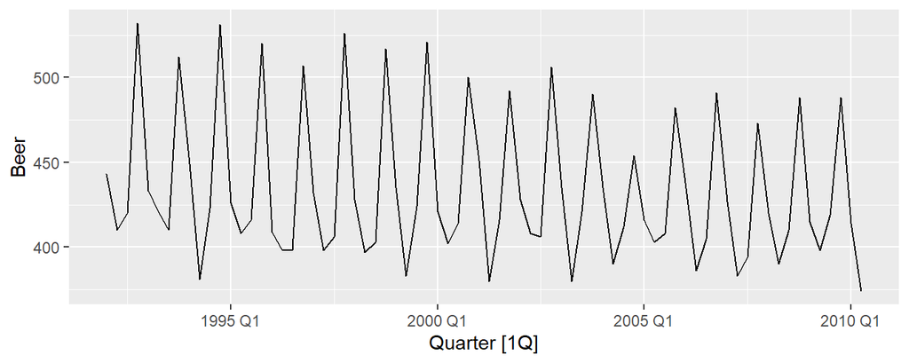

```r
beer <- aus_production |>
  select(Quarter, Beer) |>
  filter(year(Quarter) >= 1992)
beer |> autoplot(Beer)
```

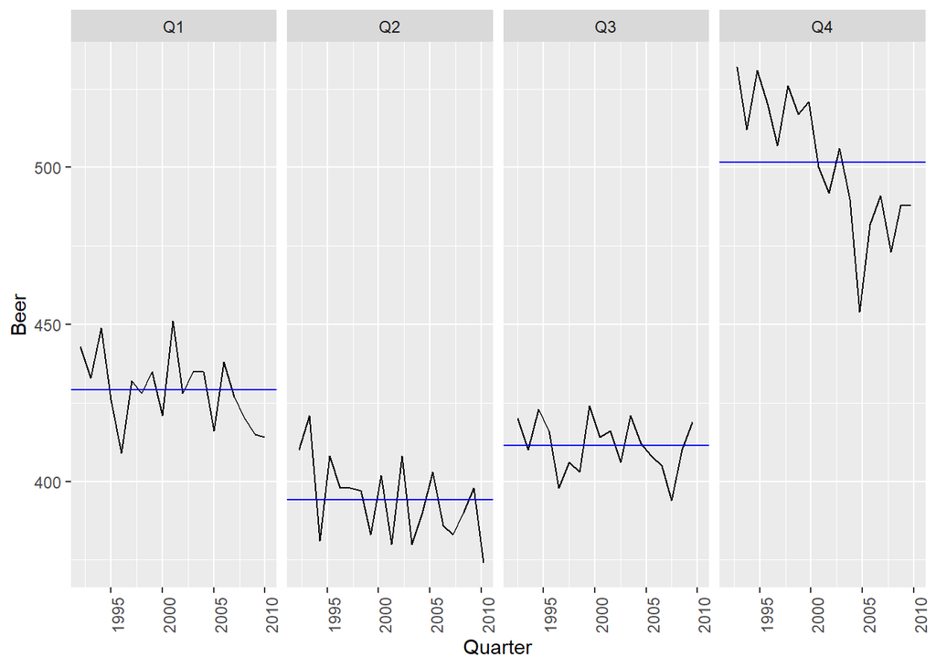

```r
beer |> gg_subseries(Beer)
```

Again we can see that Q4 is the highest quarter of demand! Now however we can see that the decreasing trend in the overall series is arising from Q4 demand going down!

## Australian holidays

```r
holidays <- tourism |>
  filter(Purpose == "Holiday") |>
  group_by(State) |>
  summarise(Trips = sum(Trips))
```

```
## # A tsibble: 640 x 3 [1Q]
## # Key:       State [8]
##    State Quarter Trips
##    <chr>   <qtr> <dbl>
##  1 ACT   1998 Q1  196.
##  2 ACT   1998 Q2  127.
##  3 ACT   1998 Q3  111.
##  4 ACT   1998 Q4  170.
##  5 ACT   1999 Q1  108.
##  6 ACT   1999 Q2  125.
##  7 ACT   1999 Q3  178.
##  8 ACT   1999 Q4  218.
##  9 ACT   2000 Q1  158.
## 10 ACT   2000 Q2  155.
## # ℹ 630 more rows
```

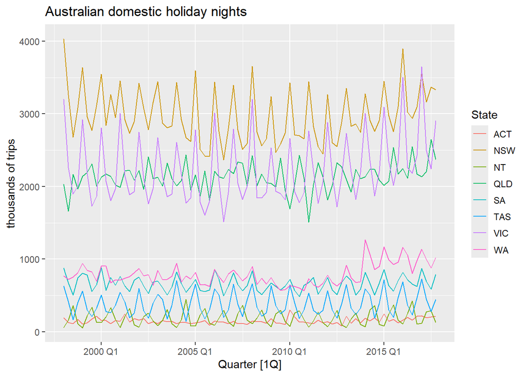

```r
holidays |> autoplot(Trips) +
  labs(y = "thousands of trips", title = "Australian domestic holiday nights")
```

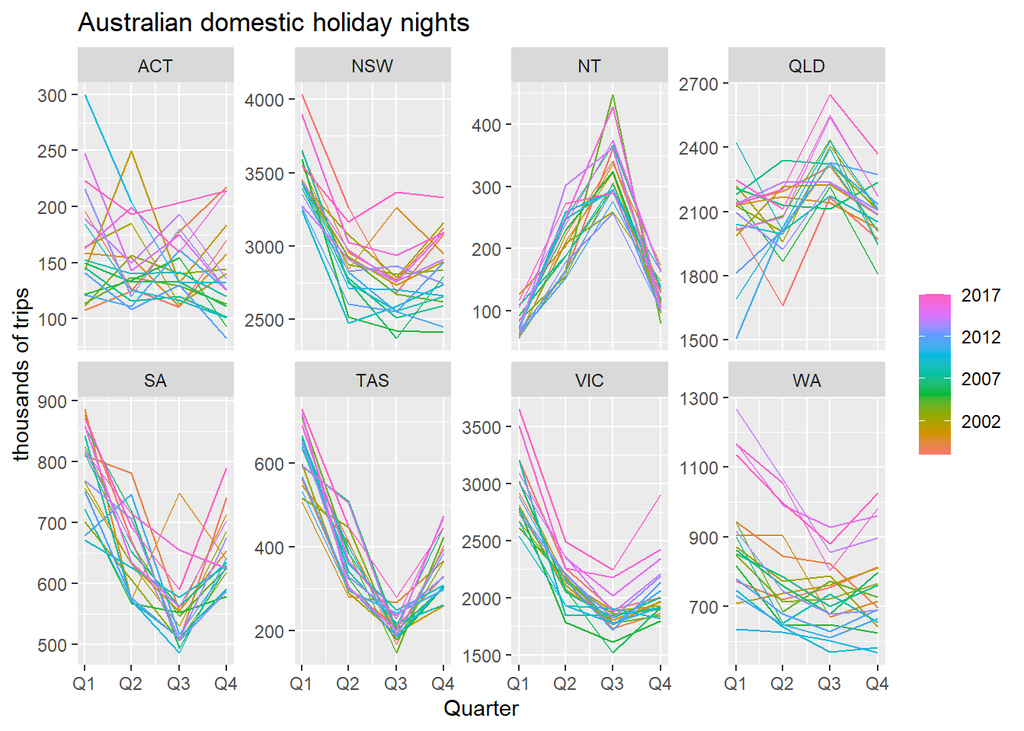

```r
holidays |> gg_season(Trips) +
   facet_wrap(vars(State), nrow = 2, scales = "free_y")+
   labs(y = "thousands of trips", title = "Australian domestic holiday nights")
```

The seasonality plots, ordered by state, we can actually see that the seasonality is very different for different states. This has to do with the weather situation in the different states of Australia. For instance NT, peak demand is in the winter quarter in Australia.

We can also consider the subseries plots:

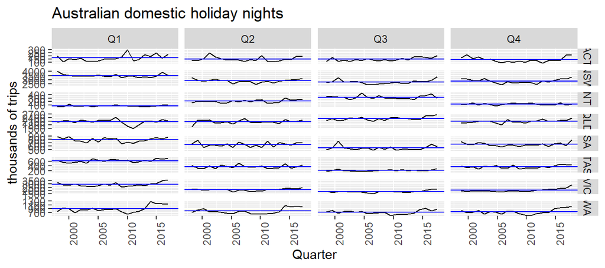

```r
holidays |>
  gg_subseries(Trips) +
  labs(y = "thousands of trips", title = "Australian domestic holiday nights")
```

In this case, the subseries plot doesn’t reaveal much more.

# 5. Scatterplot

This section serves to uncover relationship between multiple time series!

## Electricity Demand in Victoria, Australia

```r
vic_elec_day_type <- vic_elec |>
   filter(year(Time) == 2014) |>
   mutate(Day_Type = case_when(
      Holiday ~ "Holiday",
      wday(Date) %in% 2:6 ~ "Weekday", ## Define Monday-Friday as weekdays
      TRUE ~ "Weekend"))
vic_elec_day_type
```

```
## # A tsibble: 17,520 x 6 [30m] <Australia/Melbourne>
##    Time                Demand Temperature Date       Holiday Day_Type
##    <dttm>               <dbl>       <dbl> <date>     <lgl>   <chr>
##  1 2014-01-01 00:00:00  4092.        18.7 2014-01-01 TRUE    Holiday
##  2 2014-01-01 00:30:00  4198.        18.1 2014-01-01 TRUE    Holiday
##  3 2014-01-01 01:00:00  3915.        18.2 2014-01-01 TRUE    Holiday
##  4 2014-01-01 01:30:00  3673.        17.9 2014-01-01 TRUE    Holiday
##  5 2014-01-01 02:00:00  3498.        17.6 2014-01-01 TRUE    Holiday
##  6 2014-01-01 02:30:00  3339.        16.8 2014-01-01 TRUE    Holiday
##  7 2014-01-01 03:00:00  3204.        16.3 2014-01-01 TRUE    Holiday
##  8 2014-01-01 03:30:00  3100.        16.6 2014-01-01 TRUE    Holiday
##  9 2014-01-01 04:00:00  3039.        16.6 2014-01-01 TRUE    Holiday
## 10 2014-01-01 04:30:00  3012.        16.7 2014-01-01 TRUE    Holiday
## # ℹ 17,510 more rows
```

## Time plots

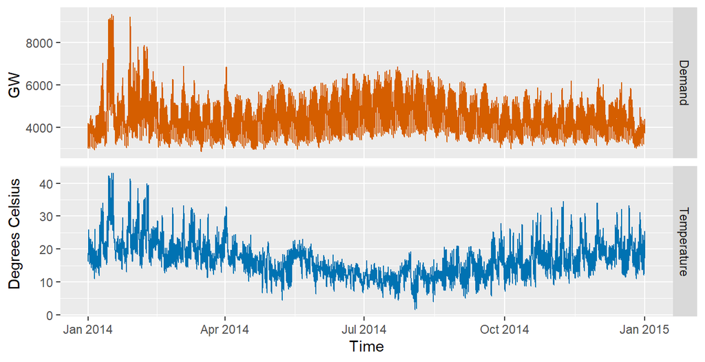

(again the first few months correspond to summer in Australia.)

## Scatterplots

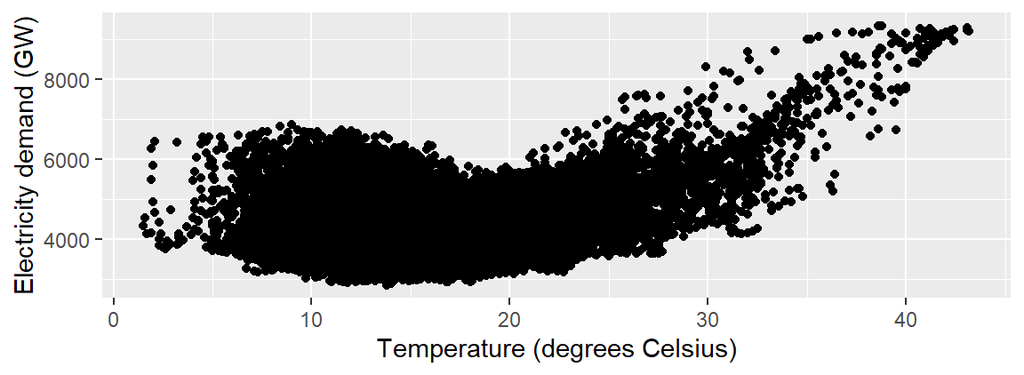

```r
vic_elec_day_type |>
  ggplot(aes(x = Temperature, y = Demand)) +
  geom_point() +
   labs(x = "Temperature (degrees Celsius)", y = "Electricity demand (GW)")
```

There seems to be a nonlinear relationship between the two variables, where on the left hand-side heating is responsible for the electricty demand, while on the right side of the plot it is air conditioning that seem to drive demand.

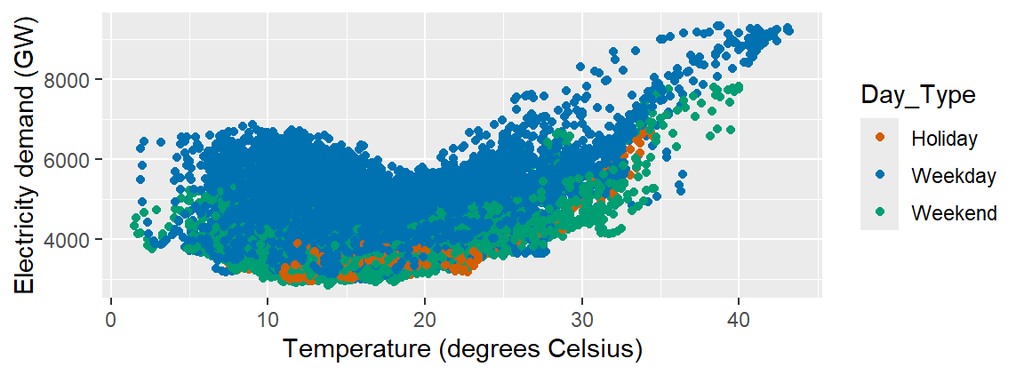

```r
vic_elec_day_type |>
  ggplot(aes(x = Temperature, y = Demand, colour = Day_Type)) +
  geom_point() +
   labs(x = "Temperature (degrees Celsius)", y = "Electricity demand (GW)")
```

Split up between Holidays/Weekdays and Weekend. This reveals lower demands for the weekend, but with the same shape of demand. Moreover, Holiday days seem to behave similarly to weekends.

## Correlation coefficient

Measures the extent of a linear relationship between two variables ($Y$ and $X$).

- $r=\frac{\sum_{t=1}^T(Y_t-\bar{Y})(X_t-\bar{X})}{\sqrt{\sum_{t=1}^T(Y_t-\bar{Y})^2} \sqrt{\sum_{t=1}^T(X_t-\bar{X})^2}}$

Note that r would not be able to fully capture the nonlinar relationship displayed above. Many generalization nowadays that measure more than just linear relations, such as distance correlation (as we see later).